# Tutorial 4 - Monte Carlo Methods

```python
import numpy as np
import matplotlib.pyplot as plt
import random
```

# Exercice N°1

## 1. Formalize the problem as a Markov decision process (MDP).

The MDP is defined as follows

- state sapce : The state space consists of all possible agent positions in the 4x4 grid.
  - $S=\{(i,j); i, j ∈ \{0,1, 2,3\} \}$
  - $S= \{(0,0), (0,1), (0,2),(0,3),(1,0),(1,1),(1,2),(1,3),(2,0), (2,1), (2,2), (2,3),(3,0), (3,1), (3,2),(3,3)\}$
- action space :
  - $A=\{Up, Down, Left, Right\} = \{0,1,2,3\}$
  - $A=\{(\Delta i,\Delta j ) ; \Delta i, \Delta j ∈\{-1, 0, 1\} and |\Delta i|+|\Delta j|=1 \}$
  - $A=\{(-1,0), (+1,0), (0,-1), (0,+1)\}$
- Reward function : is function of state and next state
  - R(s, s') = -10, if s=s'
  - R(s,s')=50 if s' is terminal state
  - R(s, s') = -1 otherwise (if s≠s' and s'≠ terminal state)
- Transition Probability Function:
  - P(s' | s, a) = 1 if: **s**=**s'** and **a** is non-permitted action
  - P(s'| s, a) = 1 if: **s'** is adjacent to **s** in the direction of **a**, and both **s'** and s are free states.
  - P(s' | s, a) = 0 otherwise
- $\gamma = 0.7$

## Plot and Print Function

```python
def maze_render(maze,start_state,exit_state):
    nrows, ncols=maze.shape
    _, ax2 =plt.subplots()
    ax2.set_xticks(np.arange(0.5, nrows, step=1))
    ax2.set_xticklabels([])
    ax2.set_yticks(np.arange(0.5, ncols, step=1))
    ax2.set_yticklabels([])
    ax2.grid(True)

    ax2.plot(*reversed(start_state), "s", markersize=30)
    ax2.text(*reversed(start_state), "start", ha="center", va="center", color="white")

    ax2.plot(*reversed(exit_state), "gs", markersize=30)  # exit is a big green square
    ax2.text(*reversed(exit_state), "Exit", ha="center", va="center", color="white")

    ax2.imshow(maze, cmap="binary")
    plt.show()
```

```python
def render_policy(policy, maze, start_state,exit_state):
    nrows, ncols=maze.shape
    _, ax2 =plt.subplots()
    ax2.set_xticks(np.arange(0.5, nrows, step=1))
    ax2.set_xticklabels([])
    ax2.set_yticks(np.arange(0.5, ncols, step=1))
    ax2.set_yticklabels([])
    ax2.grid(True)

    # "bs" -> blue square
    # "gs" -> green square
    ax2.plot(*start_state, "s", markersize=30)
    ax2.text(*start_state, "start", ha="center", va="center", color="white")

    ax2.plot(*exit_state, "gs", markersize=30)  # exit is a big green square
    ax2.text(*exit_state, "Exit", ha="center", va="center", color="white")

    # render policy
    free_cells = [(row, col)
            for row in range(nrows)
                for col in range(ncols)
                if maze[row][col] == 0
        ]

    for cell in free_cells:
        if isinstance(policy[cell], (np.int64, np.int32)) : # check if policy is deterministic or stochastic
            dx = 0
            dy = 0
            #actions = [up, down, left, right] = [0,1,2,3]
            if policy[cell] == 0:
                dy = -0.2
            if policy[cell] == 1:
                dy = 0.2
            if policy[cell] == 2:
                dx = -0.2
            if policy[cell] == 3:
                dx = 0.2
            ax2.arrow(cell[1],cell[0], dx, dy, color="red", head_width=0.1, head_length=0.1)
        else:
            for (i,value) in enumerate(policy[cell]):
                dx = 0
                dy = 0
                if i == 0:
                    dy = -0.5*value
                if i == 1:
                    dy = 0.5*value
                if i == 2:
                    dx = -0.5*value
                if i == 3:
                    dx = 0.5*value

                # *cell are the starting coordinates of the arrow.
                # dx and dy are the arrow's length and direction.
                ax2.arrow(cell[1],cell[0], dx, dy, color="red", head_width=0.1, head_length=0.1)

    ax2.imshow(maze, cmap="binary")
    plt.show()
```

```python
def render_value(V):
    nrows, ncols=V.shape
    plt.imshow(V, cmap='Greys')
    for i in range(nrows):
        for j in range (ncols):
            plt.text(j, i, f'{V[i, j]}', ha='center', va='center', color='r', fontsize=10)
    plt.xticks([]) # Hide the x-axis values
    plt.yticks([]) # Hide the y-axis values
    plt.show()
```

## Initialization

```python
maze = np.array([
    [0, 1, 0, 0],
    [0, 1, 0, 1],
    [0, 0, 0, 1],
    [0, 1, 0, 0],
])
nrows, ncols = maze.shape
start_state= (0,0) # start_cell
exit_state=(nrows-1,ncols-1)
time_limit=50

nA=4
gamma=0.7
num_episodes=1000
epsilon=0.9
```

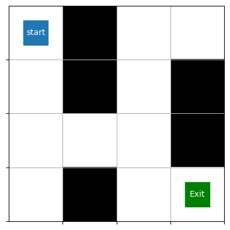

```python
maze_render(maze, start_state,exit_state)
```

## 2. Implement the reward () function that returns the scalar value the agent receives after performing a given action

```python
def get_reward(state,nxtState):
    if state==nxtState:
        return -10
    elif nxtState==exit_state:
        return 50
    else:
        return -1

get_reward((0,0),(1,0)), get_reward((3,2),(3,3)), get_reward((3,3),(3,3))
```

```
(-1, 50, -10)
```

## 3. Implement the next_state() function that returns the next state after the agent performs an action

```python
#actions = [up, down, left, right] = [0,1,2,3]
action_space=[(-1,0), (1,0), (0,-1), (0,1)]
def getNextState(state,action):
    action=action_space[action]
    nxtState=(state[0]+action[0],state[1]+action[1])

    # check if the next state legal
    if (nxtState[0]>=0 and nxtState[0]<nrows and nxtState[1]>=0 and nxtState[1]<ncols):
        if maze[nxtState]==0:
            return nxtState
        else:
            return state
    else:
        return state

getNextState((0,0),0), getNextState((0,0),1), getNextState((3,2),3)
```

```
((0, 0), (1, 0), (3, 3))
```

## 4. Implement step() function that runs one time-step of the environment's dynamics using the agent's actions.

```python
def step(state,action):
    nxtState=getNextState(state,action)
    reward=get_reward(state,nxtState)
    return nxtState,reward,nxtState==exit_state
```

## 5. First-visit MC prediction for prediction

[figure not shown]

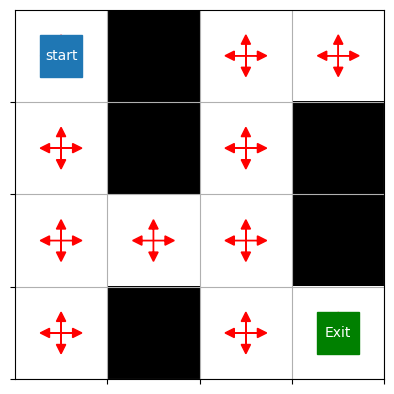

```python
policy1=np.full((nrows,ncols,nA), 1/nA)
render_policy(policy1, maze, start_state,exit_state)
```

```python
def select_action(state,policy)-> int:
    prob_a=policy[state]
    action=np.random.choice(nA,p=prob_a)
    return action
```

```python
def get_trajectory(policy):
    trajectory=[]
    time_step=0
    done=False
    state=start_state
    while not done:
        action =select_action(state, policy)
        time_step+=1
        nxtState,reward,win=step(state,action)
        sar=[state,action,reward]
        trajectory.append(sar)
        state=nxtState
        done=win or time_step==time_limit
    return trajectory
```

```python
def first_visit_monte_carlo_prediction(policy,num_eps=num_episodes):
    value_function=np.zeros((nrows,ncols))
    returns={}
    for i in range(num_eps):
        trajectory= get_trajectory(policy)
        G = 0
        T = len(trajectory) - 1
        for t, sar in enumerate(reversed(trajectory)):
            s, a, r = sar
            G= r + gamma * G

            # check if is the first visit of a state
            first_visit = True
            for j in range(T - t):
                if s == trajectory[j][0]:
                    first_visit = False
                    break

            # add return only for the first visit of a state.
            if first_visit:
                if s in returns:
                    returns[s].append(G)
                else:
                    returns[s] = [G]
                value_function[s] = np.round(np.mean(returns[s]), 2)  # rounds the  mean two decimal places
    return value_function
```

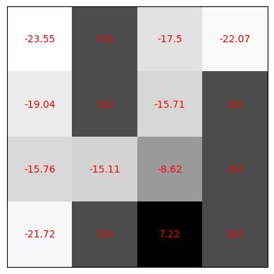

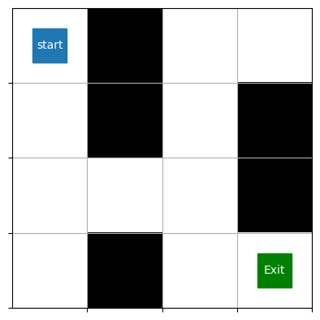

```python
V=first_visit_monte_carlo_prediction(policy1)
render_value(V)
maze_render(maze,start_state,exit_state)
```

## 6.a. Monte Carlo Control method: Monte Carlo Exploring Starts

[figure not shown]

```python
def get_trajectory_random_init(policy):
    trajectory=[]
    time_step=0
    done=False
    # Starting the trajectories with a random action selected in a random initial state.
    # (To address the problem of exploration)
    state=random.choice([(i,j)
                for i in  range(nrows)
                    for j in range(ncols)
                        if maze[(i,j)]==0 and (i,j)!=exit_state
            ])
    action=np.random.choice(nA)
    while not done:
        if time_step>0: #In the first step, the action is selected randomly, but other actions are selected based on the policy
            action =policy[state]
        time_step+=1
        nxtState,reward,win=step(state,action)
        sar=[state,action,reward]
        trajectory.append(sar)
        state=nxtState
        done=win or time_step==time_limit
    return trajectory
```

```python
def monte_carlo_es(num_eps=num_episodes):
    action_value=np.zeros((nrows,ncols,nA))
    policy=np.random.randint(0, 4, (nrows,ncols)) # Initialize a random deterministic policy by assigning random actions to each state
    returns={} # Initialize a dictionary to store returns for each state-action pair
    for _ in range(num_eps):
        trajectory= get_trajectory_random_init(policy)
        G = 0
        T = len(trajectory) - 1
        for t, sar in enumerate(reversed(trajectory)):
            s, a, r = sar
            G= r + gamma * G

            # check if is the first visit of a state-action pair   (not only state)
            first_visit = True
            for j in range(T - t):
                if s == trajectory[j][0] and a == trajectory[j][1]:
                    first_visit = False

            # add return only for the first visit of a state.
            if first_visit:
                if (s[0],s[1],a) in returns:
                    returns[s[0],s[1],a].append(G)
                else:
                    returns[(s[0],s[1],a)] = [G]
                action_value[s][a] = np.round(np.mean(returns[s[0],s[1],a]), 2)  # rounds the  mean two decimal places
                policy[s]=np.argmax(action_value[s])
    # print(returns)
    return policy
```

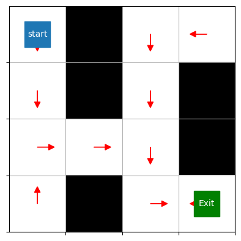

```python
p1=monte_carlo_es()
render_policy(p1, maze, start_state,exit_state)
```

## 6.b. Monte Carlo Control method: On-policy first-visit MC control

[figure not shown]

A* is the greedy action with respect to Q(s,a)

```python
def get_trajectory_from_stochastic_policy(policy):
    trajectory=[]
    time_step=0
    done=False
    state=start_state
    while not done:
        action=np.random.choice(nA,p=policy[state])
        time_step+=1
        nxtState,reward,win=step(state,action)
        sar=[state,action,reward]
        trajectory.append(sar)
        state=nxtState
        done=win or time_step==time_limit
    return trajectory
```

```python
def epsilon_soft_policy(eps, a_best):
    prob_a = np.zeros(nA)

    for a in range(nA):
        if a == a_best:
            prob_a[a] = 1 - eps + eps/nA
        else:
            prob_a[a] = eps/nA
    return prob_a
```

```python
def monte_carlo_epsilon_soft(eps=0.3,num_eps=num_episodes):
    Q=np.zeros((nrows,ncols,nA))
    policy=np.full((nrows,ncols,nA), 1/nA)# random deterministic policy
    returns={}
    for _ in range(num_eps):
        trajectory= get_trajectory_from_stochastic_policy(policy)
        G = 0
        T = len(trajectory) - 1
        for t, sar in enumerate(reversed(trajectory)):
            s, a, r = sar
            G= r + gamma * G

            # check if is the first visit of a state
            first_visit = True
            for j in range(T - t):
                if s == trajectory[j][0] and a == trajectory[j][1]:
                    first_visit = False

            # add return only for the first visit of a state.
            if first_visit:
                if (s[0],s[1],a) in returns:
                    returns[(s[0],s[1],a)].append(G)
                else:
                    returns[(s[0],s[1],a)] = [G]
                Q[s][a] = np.round(np.mean(returns[s[0],s[1],a]), 2)  # rounds the  mean two decimal places
                a_best=np.argmax(Q[s])
                policy[s]=epsilon_soft_policy(eps, a_best)
    return policy,returns
```

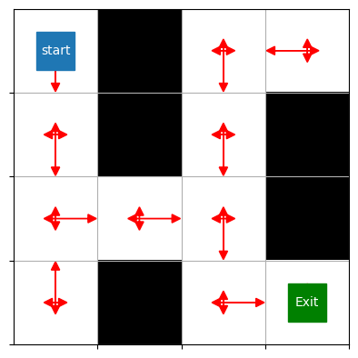

```python
p2,returns=monte_carlo_epsilon_soft()
render_policy(p2,maze, start_state,exit_state)
```

## 6.c. Monte Carlo Control method: Off-policy MC control

[figure not shown]

```python
def random_policy():
    return np.full((nrows,ncols,nA), 1/nA)
```

```python
def off_policy_monte_carlo(num_eps=num_episodes):
    Q=np.zeros((nrows,ncols,nA))
    C=np.zeros((nrows,ncols,nA))
    target_policy= np.array([[np.argmax(Q[i, j]) for j in range(ncols)] for i in range(nrows)])
    for _ in range(num_eps):
        behavior_policy=random_policy()
        trajectory= get_trajectory_from_stochastic_policy(behavior_policy)
        G = 0
        W=1
        T = len(trajectory) - 1
        for t, sar in enumerate(reversed(trajectory)):
            s, a, r = sar
            G= r + gamma * G

            C[s][a]+=W
            Q[s][a]+=(W/C[s][a])*(G-Q[s][a])
            target_policy[s]=np.argmax(Q[s])

            if(a!=target_policy[s]):
                break

            W=W/behavior_policy[s][a]

    return target_policy
```

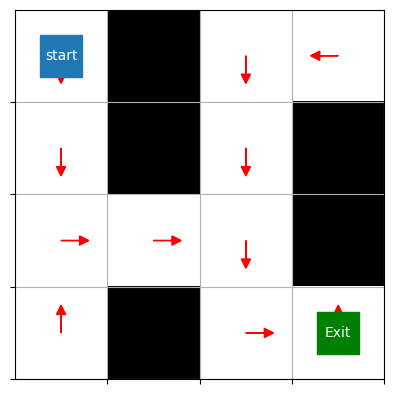

```python
p3=off_policy_monte_carlo()
render_policy(p3, maze, start_state,exit_state)
```

## What is the main difference between Monte Carlo (MC) and the Dynamic programming (DP) methods?

- DP requires complete knowledge of the environment, while MC methods do not require a model of the environment (model-free).
- DP uses bootstrapping to estimate value functions (updating estimates based on other estimates), while MC uses returns from sample episodes, which requires waiting for episode termination.